# Directory of Visualization

Edward Coleman

02-22-2024

# 1 Data Summary

We first read in two data sets called “income” and “life” representing income and life expectancy values throughout a multitude of years. “Income” has 193 observations with 220 total variables whilst “Life” has 187 observations and 220 total variables. Next, we reshape both data sets such that there are only three columns (Geo, Year, Income or Life Expectancy). We then merge these two new sets into a data set called “LifeExpIncom” which now contains Geo, Year, Income, & Life Expectancy (40953 observations and 4 variables). We then read in two more sets called “country” (240 observations and 11 variables) and “pop” (195 observations and 220 variables) respectively representing country and population data. We reshape the data set “pop” so that it coincides with “LifeExpIncom” and “Country” which already have the variable Year transformed into one column. After doing this, we’re able to merge “LifeExpIncom” with “Country” and then this newly merged set with our recently transformed “pop” set, creating a set called “fin_data” (42705 observations and 15 variables). After this, all that is left is to subset the data so that we only focus on data from the year 2000. This gives us our “final_data” (195 observations and 15 variables) set:

```
##      geo                year             population       life.expectancy
##  Length:195         Length:195         Min.   :7.85e+02   Min.   :44.1
##  Class :character   Class :character   1st Qu.:1.26e+06   1st Qu.:61.2
##  Mode  :character   Mode  :character   Median :6.01e+06   Median :70.5
##                                        Mean   :3.13e+07   Mean   :67.3
##                                        3rd Qu.:1.90e+07   3rd Qu.:74.7
##                                        Max.   :1.28e+09   Max.   :81.8
##                                                           NA's   :8
##      income         alpha.2            alpha.3           country.code
##  Min.   :   529   Length:195         Length:195         Min.   :  4
##  1st Qu.:  2335   Class :character   Class :character   1st Qu.:209
##  Median :  6860   Mode  :character   Mode  :character   Median :418
##  Mean   : 13667                                         Mean   :425
##  3rd Qu.: 15700                                         3rd Qu.:643
##  Max.   :108000                                         Max.   :894
##  NA's   :8                                              NA's   :21
##   iso_3166.2           region           sub.region        intermediate.region
##  Length:195         Length:195         Length:195         Length:195
##  Class :character   Class :character   Class :character   Class :character
##  Mode  :character   Mode  :character   Mode  :character   Mode  :character
##
##
##
##
##   region.code    sub.region.code intermediate.region.code
##  Min.   :  2.0   Min.   : 15     Min.   : 5.0
##  1st Qu.:  2.0   1st Qu.: 54     1st Qu.:11.0
##  Median : 19.0   Median :154     Median :14.0
##  Mean   : 71.7   Mean   :178     Mean   :14.9
##  3rd Qu.:142.0   3rd Qu.:202     3rd Qu.:17.0
##  Max.   :150.0   Max.   :419     Max.   :29.0
##  NA's   :21      NA's   :21      NA's   :119
```

# 2 GGPlot

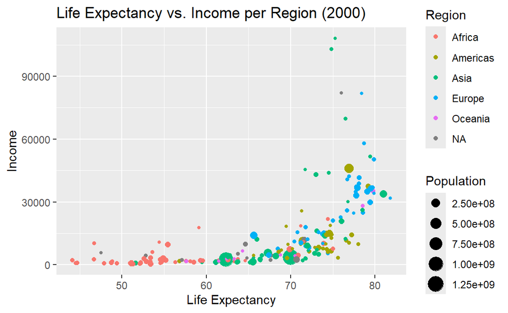

The above scatter plot shows the relationship between income, life expectancy, and population size across different regions in the year 2000. Each point is a country and the size of the points correlate with the population size of that specific region. The countries are all color coded as well.